# Labo 3

Oscar Centeno Mora

# Análisis Factorial Exploratorio (EFA)

1. Funciones para realizar el FA
2. El contenido del FA
3. Pertinencia del FA
4. La cantidad de factores
5. Las rotaciones
6. Verificación del FA
7. Introducción al FA confirmatorio

## Sitios web de referencia

Los siguientes enlaces son referentes a la aplicación del FA exploratorio en R:

http://www.di.fc.ul.pt/~jpn/r/factoranalysis/factoranalysis.html

https://quantdev.ssri.psu.edu/tutorials/intro-basic-exploratory-factor-analysis

http://www.sthda.com/english/articles/31-principal-component-methods-in-r-practical-guide/116-mfa-multiple-factor-analysis-in-r-essentials/

http://www.rpubs.com/marcelo-chavez/multivariado_1

http://halweb.uc3m.es/esp/Personal/personas/jmmarin/esp/AMult/tema4am.pdf

http://www.fuenterrebollo.com/Economicas/ECONOMETRIA/MULTIVARIANTE/FACTORIAL/analisis-factorial.pdf

https://www.statmethods.net/advstats/factor.html

https://www.r-bloggers.com/exploratory-factor-analysis-in-r/

https://data.library.virginia.edu/getting-started-with-factor-analysis/

https://rpubs.com/ranvirkumarsah/Intro2PCA_EFA

## Datos del laboratorio

Para el siguiente ejemplo utilizaremos tanto los datos de “wine” y los de “personality”

### Wine

Es un archivo de datos con la valoración en la catación de un tipo de vino, según diversas características.

```
##  [1] "Label"                         "Soil"
##  [3] "Odor.Intensity.before.shaking" "Aroma.quality.before.shaking"
##  [5] "Fruity.before.shaking"         "Flower.before.shaking"
##  [7] "Spice.before.shaking"          "Visual.intensity"
##  [9] "Nuance"                        "Surface.feeling"
## [11] "Odor.Intensity"                "Quality.of.odour"
## [13] "Fruity"                        "Flower"
## [15] "Spice"                         "Plante"
## [17] "Phenolic"                      "Aroma.intensity"
## [19] "Aroma.persistency"             "Aroma.quality"
## [21] "Attack.intensity"              "Acidity"
## [23] "Astringency"                   "Alcohol"
## [25] "Balance"                       "Smooth"
## [27] "Bitterness"                    "Intensity"
## [29] "Harmony"                       "Overall.quality"
## [31] "Typical"
```

```
##  [1] "Odor.Intensity.before.shaking" "Aroma.quality.before.shaking"
##  [3] "Fruity.before.shaking"         "Flower.before.shaking"
##  [5] "Spice.before.shaking"          "Visual.intensity"
##  [7] "Nuance"                        "Surface.feeling"
##  [9] "Odor.Intensity"                "Quality.of.odour"
## [11] "Fruity"                        "Flower"
## [13] "Spice"                         "Plante"
## [15] "Phenolic"                      "Aroma.intensity"
## [17] "Aroma.persistency"             "Aroma.quality"
## [19] "Attack.intensity"              "Acidity"
## [21] "Astringency"                   "Alcohol"
## [23] "Balance"                       "Smooth"
## [25] "Bitterness"                    "Intensity"
## [27] "Harmony"                       "Overall.quality"
## [29] "Typical"
```

La estructura del archivo wine:

```
## 'data.frame':    21 obs. of  29 variables:
##  $ Odor.Intensity.before.shaking: num  3.07 2.96 2.86 2.81 3.61 ...
##  $ Aroma.quality.before.shaking : num  3 2.82 2.93 2.59 3.43 ...
##  $ Fruity.before.shaking        : num  2.71 2.38 2.56 2.42 3.15 ...
##  $ Flower.before.shaking        : num  2.28 2.28 1.96 1.91 2.15 ...
##  $ Spice.before.shaking         : num  1.96 1.68 2.08 2.16 2.04 ...
##  $ Visual.intensity             : num  4.32 3.22 3.54 2.89 4.39 ...
##  $ Nuance                       : num  4 3 3.39 2.79 4.04 ...
##  $ Surface.feeling              : num  3.27 2.81 3 2.54 3.38 ...
##  $ Odor.Intensity               : num  3.41 3.37 3.25 3.16 3.54 ...
##  $ Quality.of.odour             : num  3.31 3 2.93 2.88 3.36 ...
##  $ Fruity                       : num  2.88 2.56 2.77 2.39 3.16 ...
##  $ Flower                       : num  2.32 2.44 2.19 2.08 2.23 ...
##  $ Spice                        : num  1.84 1.74 2.25 2.17 2.15 ...
##  $ Plante                       : num  2 2 1.75 2.3 1.76 ...
##  $ Phenolic                     : num  1.65 1.38 1.25 1.48 1.6 ...
##  $ Aroma.intensity              : num  3.26 2.96 3.08 2.54 3.62 ...
##  $ Aroma.persistency            : num  2.96 2.81 2.8 2.58 3.3 ...
##  $ Aroma.quality                : num  3.2 2.93 3.08 2.48 3.46 ...
##  $ Attack.intensity             : num  2.96 3.04 3.22 2.7 3.46 ...
##  $ Acidity                      : num  2.11 2.11 2.18 3.18 2.57 ...
##  $ Astringency                  : num  2.43 2.18 2.25 2.18 2.54 ...
##  $ Alcohol                      : num  2.5 2.65 2.64 2.5 2.79 ...
##  $ Balance                      : num  3.25 2.93 3.32 2.33 3.46 ...
##  $ Smooth                       : num  2.73 2.5 2.68 1.68 3.04 ...
##  $ Bitterness                   : num  1.93 1.93 2 1.96 2.07 ...
##  $ Intensity                    : num  2.86 2.89 3.07 2.46 3.64 ...
##  $ Harmony                      : num  3.14 2.96 3.14 2.04 3.64 ...
##  $ Overall.quality              : num  3.39 3.21 3.54 2.46 3.74 ...
##  $ Typical                      : num  3.25 3.04 3.18 2.25 3.44 ...
```

### Personality

```
##  [1] "distant" "talkatv" "carelss" "hardwrk" "anxious" "agreebl" "tense"
##  [8] "kind"    "opposng" "relaxed" "disorgn" "outgoin" "approvn" "shy"
## [15] "discipl" "harsh"   "persevr" "friendl" "worryin" "respnsi" "contrar"
## [22] "sociabl" "lazy"    "coopera" "quiet"   "organiz" "criticl" "lax"
## [29] "laidbck" "withdrw" "givinup" "easygon"
```

La estructura del archivo personality:

```
## 'data.frame':    240 obs. of  32 variables:
##  $ distant: num  -1.04 -0.483 1.189 -0.483 1.746 ...
##  $ talkatv: num  0.6656 1.2616 0.0695 0.6656 -1.7186 ...
##  $ carelss: num  -1.332 -0.78 -0.78 1.428 -0.228 ...
##  $ hardwrk: num  -2.1349 0.0547 -1.405 0.0547 -1.405 ...
##  $ anxious: num  0.995 -0.0687 -2.196 1.5268 1.5268 ...
##  $ agreebl: num  0.999 0.999 0.999 0.999 -0.459 ...
##  $ tense  : num  0.201 -0.324 -1.374 -1.374 1.252 ...
##  $ kind   : num  1.608 0.815 1.608 0.815 -3.938 ...
##  $ opposng: num  0.714 0.714 -1.162 -0.537 -0.537 ...
##  $ relaxed: num  0.31 0.9 1.49 0.9 -1.46 ...
##  $ disorgn: num  -0.51 0.431 1.372 -0.98 0.431 ...
##  $ outgoin: num  -2.2216 1.0935 -0.0115 -0.564 -2.2216 ...
##  $ approvn: num  0.835 0.835 0.835 0.104 -0.627 ...
##  $ shy    : num  2.255 0.732 0.224 -0.283 1.747 ...
```

[output cut: 18 more lines]

## Funciones y librerías del FA

Las funciones y librerías parar realizar el FA en R pueden ser:

1. MFA() (FactoMineR)

https://www.rdocumentation.org/packages/FactoMineR/versions/1.41/topics/MFA

```r
# MFA (base, group, type = rep("s",length(group)), excl = NULL,
#     ind.sup = NULL, ncp = 5, name.group = NULL,
#     num.group.sup = NULL, graph = TRUE, weight.col.mfa = NULL,
#     row.w = NULL, axes = c(1,2), tab.comp=NULL)
```

2. FA() (psych)

https://www.rdocumentation.org/packages/psych/versions/1.8.12/topics/fa

```r
# fa(r,nfactors=1,n.obs = NA,n.iter=1, rotate="oblimin", scores="regression",
# residuals=FALSE, SMC=TRUE, covar=FALSE,missing=FALSE,impute="median",
# min.err = 0.001,  max.iter = 50,symmetric=TRUE, warnings=TRUE, fm="minres",
#  alpha=.1,p=.05,oblique.scores=FALSE,np.obs=NULL,use="pairwise",cor="cor",
#  correct=.5,weight=NULL,...)
# fac(r,nfactors=1,n.obs = NA, rotate="oblimin", scores="tenBerge", residuals=FALSE,
#  SMC=TRUE, covar=FALSE,missing=FALSE,impute="median",min.err = 0.001,
# max.iter=50,symmetric=TRUE,warnings=TRUE,fm="minres",alpha=.1,
# oblique.scores=FALSE,np.obs=NULL,use="pairwise",cor="cor",correct=.5, weight=NULL,...)
#
# fa.sapa(r,nfactors=1,n.obs = NA,n.iter=1,rotate="oblimin",scores="regression",
# residuals=FALSE,SMC=TRUE,covar=FALSE,missing=FALSE,impute="median", min.err = .001,
# max.iter=50,symmetric=TRUE,warnings=TRUE,fm="minres",alpha=.1, p =.05,
# oblique.scores=FALSE,np.obs=NULL,use="pairwise",cor="cor",correct=.5,weight=NULL,
# frac=.1,...)
```

3. factanal() ()

https://www.rdocumentation.org/packages/stats/versions/3.5.2/topics/factanal

```r
# factanal(x, factors, data = NULL, covmat = NULL, n.obs = NA,
#          subset, na.action, start = NULL,
#          scores = c("none", "regression", "Bartlett"),
#          rotation = "varimax", control = NULL, …)
```

Utilizaremos esencialmente las funciones MFA y factanal

## Pertinencia del FA

### Estadísticas descriptivas

En el análisis de la reducción de variables, este análisis posee interés si algunas entre estas están correlacionadas, y por lo tanto se puede llegar a una fusión de las variables. Una forma de corroborar la correlación entre las variables es mediante el gráfico de correlaciones. Recordar que en el laboratorio vimos diversas modalidades de este gráfico.

Veamos dos ejemplos de gráficos de correlación:

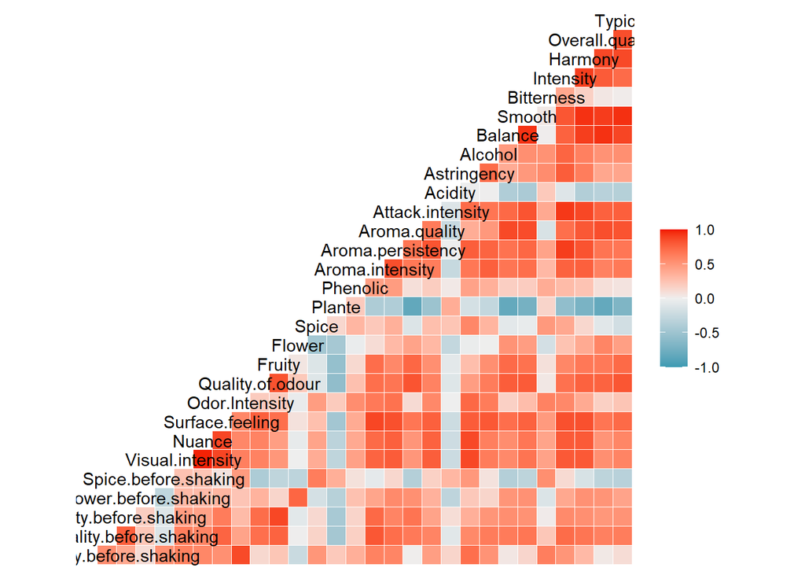

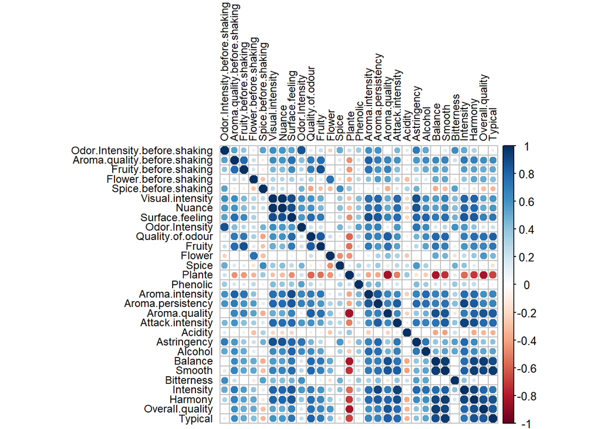

Para el presente caso de wine, se observa que efectivamente las variables están correlacionadas entre ellas, y que por lo tanto se evidencia la pertinencia de llevar a cabo un análisis de FA exploratorio.

### Pruebas estadísticas

También, se puede probar la pertinencia del análisis por FA mediante pruebas numéricas. Acá podemos recurrir a las pruebas de KMO y la Esferecidad de Bartlett

#### KMO

La prueba Kaiser Meyer Olkin (KMO) es una medida de la idoneidad de los datos para el análisis factorial. Esta estadística mide la proporción de la varianza total entre las variables, que puede ser una varianza común.

KMO devuelve valores entre 0 y 1 * Los valores entre 0,8 y 1 indican que el muestreo es adecuado. * Los valores entre 0,5 y 0,8 indican que el muestreo no es adecuado y que los datos deben corregirse antes de realizar la EPT. * Los valores por debajo de 0.5 indican que hay grandes correlaciones parciales, lo cual es un problema para el análisis factorial.

En palabras de Kaiser: * 0.00 a 0.49 inaceptable * 0.50 a 0.59 miserable * 0.60 a 0.69 mediocre. * 0.70 a 0.79 mediano * 0.80 a 0.89 meritorio * 0.90 a 1.00 maravilloso

[output not shown]

```
## Kaiser-Meyer-Olkin factor adequacy
## Call: KMO(r = corr_wine)
## Overall MSA =  0.5
## MSA for each item =
## Odor.Intensity.before.shaking  Aroma.quality.before.shaking
##                           0.5                           0.5
##         Fruity.before.shaking         Flower.before.shaking
##                           0.5                           0.5
##          Spice.before.shaking              Visual.intensity
##                           0.5                           0.5
##                        Nuance               Surface.feeling
##                           0.5                           0.5
##                Odor.Intensity              Quality.of.odour
##                           0.5                           0.5
##                        Fruity                        Flower
##                           0.5                           0.5
##                         Spice                        Plante
##                           0.5                           0.5
##                      Phenolic               Aroma.intensity
##                           0.5                           0.5
##             Aroma.persistency                 Aroma.quality
##                           0.5                           0.5
##              Attack.intensity                       Acidity
##                           0.5                           0.5
##                   Astringency                       Alcohol
##                           0.5                           0.5
##                       Balance                        Smooth
##                           0.5                           0.5
##                    Bitterness                     Intensity
##                           0.5                           0.5
##                       Harmony               Overall.quality
##                           0.5                           0.5
##                       Typical
##                           0.5
```

¿qué podemos concluir para el presente caso?

#### Esferecidad de Bartlett

La prueba de esfericidad de Bartlett contrasta la hipótesis nula de que la matriz de correlaciones es una matriz identidad, en cuyo caso no existirían correlaciones significativas entre las variables y el modelo factorial no sería pertinente.

```
## $chisq
## [1] 31177.06
##
## $p.value
## [1] 0
##
## $df
## [1] 406
```

## Estimación del primero modelo por FA

Al inicio debemos estimar un FA sin rotación, y con un número relativamente grande de factores

### Ejemplo de wine

En este caso utilizamos la función fa

```r
# fa.0 <- fa(r=wine.1, nfactors = 10, rotate = "none")
# print(fa.0)
```

```
## Factor Analysis using method =  minres
## Call: fa(r = wine.1, nfactors = 10, rotate = "none")
## Standardized loadings (pattern matrix) based upon correlation matrix
##                                 MR1   MR2   MR3   MR4   MR5   MR6   MR7   MR8
## Odor.Intensity.before.shaking  0.47  0.74 -0.03  0.20  0.04 -0.21 -0.31  0.03
## Aroma.quality.before.shaking   0.80  0.04 -0.34  0.08  0.02 -0.13 -0.14 -0.06
## Fruity.before.shaking          0.68 -0.04 -0.59  0.18  0.15 -0.29  0.01  0.00
## Flower.before.shaking          0.47 -0.31  0.51  0.42  0.09 -0.26  0.11  0.02
## Spice.before.shaking          -0.05  0.78  0.17 -0.29  0.19 -0.16 -0.09  0.08
## Visual.intensity               0.85  0.34  0.10 -0.11 -0.27 -0.04  0.06  0.23
## Nuance                         0.83  0.33  0.09 -0.17 -0.29 -0.06  0.12  0.22
## Surface.feeling                0.93  0.18 -0.08 -0.02 -0.15  0.11 -0.02  0.00
## Odor.Intensity                 0.55  0.66  0.19  0.29  0.01 -0.01 -0.21 -0.05
## Quality.of.odour               0.83 -0.28 -0.30  0.12 -0.02  0.20  0.17  0.17
## Fruity                         0.75 -0.23 -0.54  0.10  0.03  0.05 -0.12  0.05
## Flower                         0.28 -0.57  0.63  0.22  0.34  0.03 -0.11  0.03
## Spice                          0.20  0.72  0.01 -0.30  0.06 -0.20  0.33 -0.25
## Plante                        -0.60  0.60  0.02  0.38 -0.09  0.11 -0.03  0.24
## Phenolic                       0.34  0.38  0.15  0.46 -0.17  0.19  0.40 -0.08
## Aroma.intensity                0.89  0.14 -0.13  0.28 -0.15 -0.10 -0.08 -0.18
## Aroma.persistency              0.92  0.21  0.13  0.16  0.20 -0.05  0.10  0.00
## Aroma.quality                  0.81 -0.46 -0.10 -0.01  0.11 -0.12  0.13  0.00
## Attack.intensity               0.88  0.10  0.20 -0.26  0.18  0.08 -0.12  0.13
## Acidity                       -0.23  0.37 -0.33  0.06  0.63  0.10  0.23  0.22
## Astringency                    0.74  0.55  0.15 -0.13 -0.03 -0.04  0.08  0.08
## Alcohol                        0.76  0.30 -0.14  0.05  0.07  0.32 -0.05 -0.20
## Balance                        0.86 -0.44  0.06 -0.07  0.00  0.04  0.05 -0.10
## Smooth                         0.90 -0.35  0.11 -0.08 -0.08  0.03  0.00  0.04
## Bitterness                     0.31  0.68  0.10 -0.07  0.13  0.38 -0.14 -0.15
## Intensity                      0.94  0.13  0.10 -0.17  0.17 -0.02  0.06 -0.06
## Harmony                        0.95 -0.16  0.15 -0.13 -0.08 -0.04  0.03  0.01
## Overall.quality                0.83 -0.43  0.12 -0.13  0.13  0.07 -0.01 -0.09
## Typical                        0.84 -0.39  0.01 -0.06 -0.04  0.13 -0.15  0.15
##                                 MR9  MR10   h2     u2 com
## Odor.Intensity.before.shaking  0.04 -0.02 0.95 0.0473 2.5
## Aroma.quality.before.shaking  -0.03  0.01 0.80 0.2032 1.5
## Fruity.before.shaking          0.05 -0.04 0.96 0.0439 2.7
## Flower.before.shaking         -0.08 -0.07 0.86 0.1425 4.5
## Spice.before.shaking           0.04 -0.10 0.81 0.1885 1.7
## Visual.intensity               0.01 -0.10 0.99 0.0093 1.8
```

[output cut: 32 more lines]

```
## Test of the hypothesis that 10 factors are sufficient.
##
## The degrees of freedom for the null model are  406  and the objective function was  230.58 with Chi Square of  2190.5
## The degrees of freedom for the model are 161  and the objective function was  173.39
##
## The root mean square of the residuals (RMSR) is  0.01
## The df corrected root mean square of the residuals is  0.02
##
## The harmonic number of observations is  21 with the empirical chi square  1.93  with prob <  1
## The total number of observations was  21  with Likelihood Chi Square =  491.28  with prob <  4.1e-35
##
## Tucker Lewis Index of factoring reliability =  -2.368
## RMSEA index =  0.309  and the 90 % confidence intervals are  0.288 0.353
## BIC =  1.11
## Fit based upon off diagonal values = 1
```

Esto nos permite ver ciertas cosas, pero no es del todo fundamental…. Debemos verificar el número de factores que podría explicar el conjunto de datos.

### Ejemplo de personality

PAra el caso de personality, vemos el primer FA. Interesa sobre todo as funcionalidades que podemos sacar del análisis.

```r
# res1b <- factanal(personality, factors = 10, rotation = "none", na.action = na.omit)
```

```
##  [1] "converged"    "loadings"     "uniquenesses" "correlation"  "criteria"
##  [6] "factors"      "dof"          "method"       "STATISTIC"    "PVAL"
## [11] "n.obs"        "call"
```

Próximamente, veremos cómo podemos utilizar los elementos de las funciones.

## Cantidad de Factores

### Gráfico de sedimentación (Scree plot)

#### Opción 1

La forma más popular de conocer la cantidad óptima de factores es mediante el gráfico de sedimentación. Lo usual es ver dónde es que se lleva a cabo la caída más importante, o se dibuja un “codo”. A veces no es nada fácil el saber lo anterior. Personalmente considero que ante la poca claridad, hay que llevar a cabo un análisis interactivo del FA.

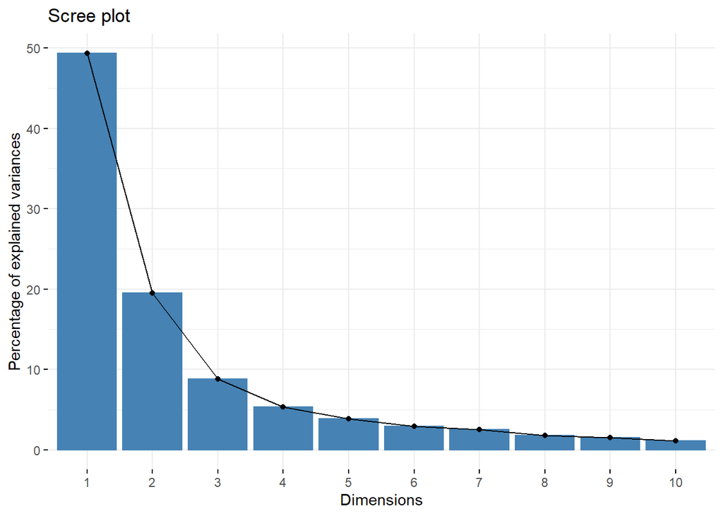

¿Cuántos factores?

#### Opción 2

R posee ciertos criterios que permiten “guiar” al analista en la elección del número de factor a elegir.

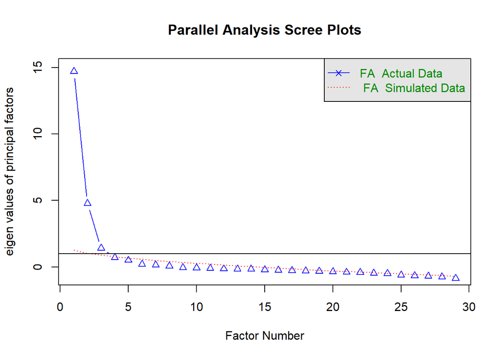

```
## Parallel analysis suggests that the number of factors =  3  and the number of components =  NA
```

```
##   noc naf nparallel nkaiser
## 1   5   1         5       5
```

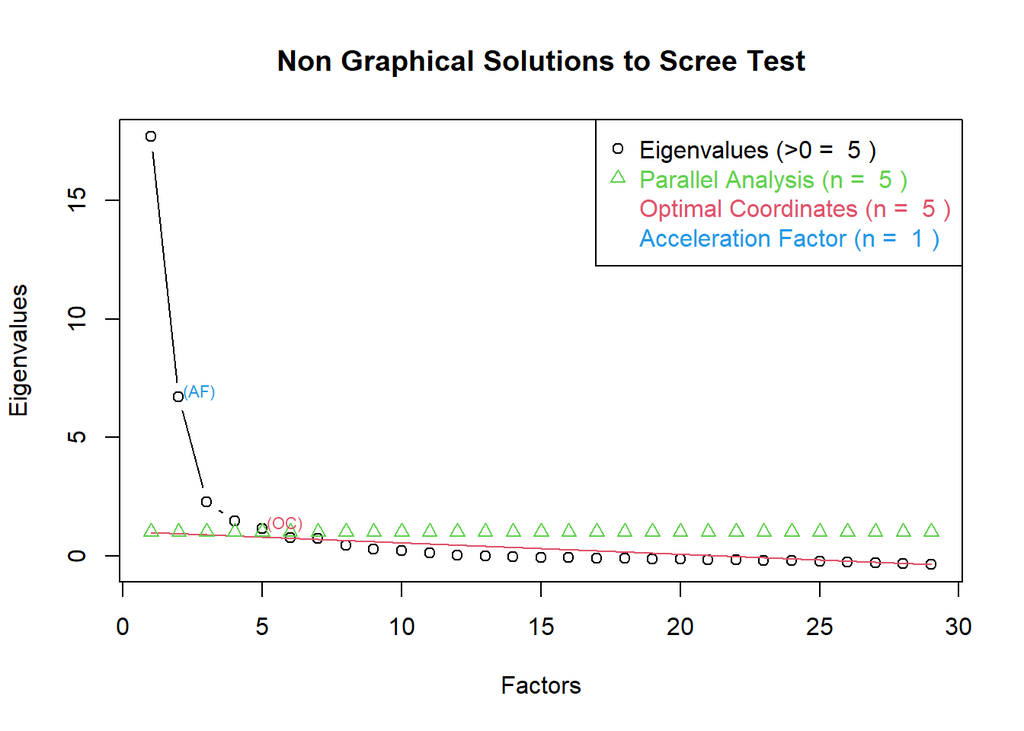

Entonces, ¿cuántos componentes debemos elegir?

## Rotaciones

Con tal de mejorar la interpretación de los resultados, es que llevamos a cabo las rotaciones. Estas permiten identificar mejorar que variable pertenece a cierto componente, y por ende brindar una claridad a la estructura de la data.

La lista de rotaciones posibles es enorme:

-Varimax -Criterio Oblimin directo -Quartimax -Equamax -Promax -Etc…

Veamos una lista más extensa de ciertas rotaciones para la función fa().

Algunas rotaciones ortogonales

```r
# fa.1 <- fa(r=wine.1, nfactors = 5, rotate = "none")
# fa.1 <- fa(r=wine.1, nfactors = 5, rotate = "varimax")
# fa.1 <- fa(r=wine.1, nfactors = 5, rotate = "quartimax")
# fa.1 <- fa(r=wine.1, nfactors = 5, rotate = "bentlerT")
# fa.1 <- fa(r=wine.1, nfactors = 5, rotate = "equamax")
# fa.1 <- fa(r=wine.1, nfactors = 5, rotate = "varimin")
# fa.1 <- fa(r=wine.1, nfactors = 5, rotate = "geominT")
# fa.1 <- fa(r=wine.1, nfactors = 5, rotate = "bifactor")
```

```r
# fa.1 <- fa(r=wine.1, nfactors = 5, rotate = "none")
# fa.1 <- fa(r=wine.1, nfactors = 5, rotate = "varimax")
# fa.1 <- fa(r=wine.1, nfactors = 5, rotate = "quartimax")
# fa.1 <- fa(r=wine.1, nfactors = 5, rotate = "bentlerT")
# fa.1 <- fa(r=wine.1, nfactors = 5, rotate = "equamax")
# fa.1 <- fa(r=wine.1, nfactors = 5, rotate = "varimin")
# fa.1 <- fa(r=wine.1, nfactors = 5, rotate = "geominT")
# fa.1 <- fa(r=wine.1, nfactors = 5, rotate = "bifactor")
```

En nuestro caso de wine utilizaromos una rotación varimax

```r
fa.1 <- fa(r=wine.1, nfactors = 3, rotate = "varimax")
```

También, para el caso de personality utilizaremos una rotación varimax

```r
res1a <- factanal(personality, factors = 5, rotation = "varimax", na.action = na.omit)
```

## Resultados de los FA: general, cargas y las comunalidades

### General

De forma general podemos ver diversos resultados del análisis del FA.

```r
fa.0 <- fa(r=personality, nfactors = 5, rotate = "varimax")
print(fa.0)
```

```
## Factor Analysis using method =  minres
## Call: fa(r = personality, nfactors = 5, rotate = "varimax")
## Standardized loadings (pattern matrix) based upon correlation matrix
##           MR1   MR2   MR4   MR5   MR3   h2   u2 com
## distant  0.59  0.08  0.08 -0.11  0.30 0.46 0.54 1.7
## talkatv -0.76  0.03 -0.02  0.12  0.16 0.62 0.38 1.2
## carelss  0.02  0.60  0.09 -0.03  0.28 0.45 0.55 1.5
## hardwrk -0.20 -0.65  0.14  0.11  0.10 0.50 0.50 1.4
## anxious  0.17  0.08  0.70  0.16  0.22 0.59 0.41 1.5
## agreebl -0.02  0.02 -0.06  0.64 -0.17 0.44 0.56 1.2
## tense    0.16  0.01  0.77  0.01  0.26 0.70 0.30 1.3
## kind    -0.10 -0.31  0.03  0.61 -0.18 0.51 0.49 1.8
## opposng -0.01  0.11  0.09 -0.13  0.63 0.43 0.57 1.2
## relaxed -0.02  0.13 -0.69  0.34 -0.07 0.62 0.38 1.6
## disorgn -0.01  0.72  0.00  0.04  0.15 0.55 0.45 1.1
## outgoin -0.83 -0.08 -0.05  0.22  0.00 0.74 0.26 1.2
## approvn -0.27 -0.13 -0.12  0.51 -0.12 0.37 0.63 1.9
## shy      0.72  0.20  0.16  0.00 -0.09 0.58 0.42 1.3
## discipl  0.03 -0.63  0.04  0.09  0.09 0.42 0.58 1.1
## harsh    0.07  0.13  0.07 -0.22  0.64 0.48 0.52 1.4
## persevr -0.16 -0.54  0.11  0.19  0.09 0.38 0.62 1.6
## friendl -0.50 -0.17  0.06  0.55 -0.16 0.60 0.40 2.4
## worryin  0.18  0.05  0.73  0.05  0.13 0.59 0.41 1.2
## respnsi -0.01 -0.73  0.06  0.23  0.02 0.59 0.41 1.2
## contrar  0.05  0.14  0.15 -0.15  0.72 0.58 0.42 1.3
## sociabl -0.72  0.01 -0.09  0.26 -0.10 0.60 0.40 1.3
## lazy     0.19  0.68  0.07  0.03  0.13 0.51 0.49 1.3
## coopera -0.10 -0.18 -0.11  0.57 -0.28 0.46 0.54 1.9
## quiet    0.80  0.10  0.17  0.16  0.00 0.70 0.30 1.2
## organiz -0.06 -0.76 -0.02  0.06 -0.06 0.58 0.42 1.0
## criticl  0.09 -0.17  0.14 -0.11  0.58 0.40 0.60 1.4
## lax      0.04  0.47 -0.22  0.23  0.10 0.33 0.67 2.1
## laidbck -0.03  0.25 -0.59  0.28  0.09 0.50 0.50 1.9
## withdrw  0.73  0.14  0.13 -0.09  0.27 0.66 0.34 1.5
## givinup  0.36  0.46  0.22 -0.10  0.13 0.42 0.58 2.7
## easygon -0.13  0.13 -0.44  0.43 -0.02 0.42 0.58 2.4
##
##                        MR1  MR2  MR4  MR5  MR3
## SS loadings           4.51 4.43 2.97 2.52 2.36
## Proportion Var        0.14 0.14 0.09 0.08 0.07
```

[output cut: 10 more lines]

```
## The root mean square of the residuals (RMSR) is  0.04
## The df corrected root mean square of the residuals is  0.05
##
## The harmonic number of observations is  240 with the empirical chi square  355.07  with prob <  0.36
## The total number of observations was  240  with Likelihood Chi Square =  710.66  with prob <  2.2e-27
##
## Tucker Lewis Index of factoring reliability =  0.849
## RMSEA index =  0.066  and the 90 % confidence intervals are  0.059 0.073
## BIC =  -1185.64
## Fit based upon off diagonal values = 0.98
## Measures of factor score adequacy
##                                                    MR1  MR2  MR4  MR5  MR3
## Correlation of (regression) scores with factors   0.96 0.94 0.93 0.90 0.89
## Multiple R square of scores with factors          0.91 0.89 0.86 0.81 0.79
## Minimum correlation of possible factor scores     0.83 0.78 0.72 0.62 0.58
```

### Cargas y correlaciones

El análisis que mejorar identifica la estructura de los datos son las cargas factorias de las variables a los factores

```r
res1a <- factanal(personality, factors = 5, rotation = "varimax", na.action = na.omit)
names(res1b)
```

```
##  [1] "converged"    "loadings"     "uniquenesses" "correlation"  "criteria"
##  [6] "factors"      "dof"          "method"       "STATISTIC"    "PVAL"
## [11] "n.obs"        "call"
```

```r
res1a$loadings
```

```
##
## Loadings:
##         Factor1 Factor2 Factor3 Factor4 Factor5
## distant  0.575                  -0.117   0.311
## talkatv -0.767                   0.121   0.159
## carelss          0.622                   0.272
## hardwrk -0.201  -0.633   0.141   0.108
## anxious  0.162           0.715   0.143   0.211
## agreebl                          0.635  -0.164
## tense    0.153           0.785           0.258
## kind            -0.318           0.621  -0.183
## opposng          0.106          -0.120   0.637
## relaxed          0.137  -0.680   0.353
## disorgn          0.745                   0.145
## outgoin -0.827                   0.221
## approvn -0.274  -0.126  -0.106   0.500  -0.115
## shy      0.734   0.193   0.160
## discipl         -0.616
## harsh            0.124          -0.230   0.644
## persevr -0.161  -0.525   0.110   0.194
## friendl -0.496  -0.167           0.548  -0.165
## worryin  0.176           0.745           0.122
## respnsi         -0.724           0.238
## contrar          0.142   0.150  -0.147   0.710
## sociabl -0.712                   0.272  -0.101
## lazy     0.194   0.660                   0.127
## coopera         -0.179  -0.110   0.554  -0.280
## quiet    0.801           0.170   0.161
## organiz         -0.776
## criticl         -0.176   0.140  -0.105   0.572
## lax              0.470  -0.207   0.231
## laidbck          0.256  -0.562   0.290
## withdrw  0.718   0.145   0.127  -0.100   0.273
## givinup  0.359   0.442   0.222  -0.109   0.144
## easygon -0.136   0.129  -0.426   0.433
##
##                Factor1 Factor2 Factor3 Factor4 Factor5
## SS loadings      4.500   4.423   2.958   2.536   2.356
## Proportion Var   0.141   0.138   0.092   0.079   0.074
## Cumulative Var   0.141   0.279   0.371   0.451   0.524
```

```r
res1a <- factanal(personality, factors = 5, rotation = "varimax", na.action = na.omit)
names(res1b)
```

```
##  [1] "converged"    "loadings"     "uniquenesses" "correlation"  "criteria"
##  [6] "factors"      "dof"          "method"       "STATISTIC"    "PVAL"
## [11] "n.obs"        "call"
```

```r
res1a$correlation
```

```
##             distant     talkatv       carelss     hardwrk     anxious
## distant  1.00000000 -0.44293078  1.778832e-01 -0.15553288  0.23079517
## talkatv -0.44293078  1.00000000  6.822117e-02  0.16545831 -0.10396208
## carelss  0.17788317  0.06822117  1.000000e+00 -0.24374534  0.17961979
## hardwrk -0.15553288  0.16545831 -2.437453e-01  1.00000000  0.05737214
## anxious  0.23079517 -0.10396208  1.796198e-01  0.05737214  1.00000000
## agreebl -0.11871228  0.09563076  9.616542e-03  0.03855806  0.06242840
## tense    0.23718731 -0.10572767  1.248765e-01  0.11722515  0.67993263
## kind    -0.20490182  0.12088309 -3.003257e-01  0.21889138  0.02627449
## opposng  0.19604634  0.08270689  1.849294e-01 -0.08507621  0.18979064
## relaxed -0.14148435  0.03724641 -3.408964e-05 -0.14142446 -0.41867234
## disorgn  0.13122729  0.06842526  6.211897e-01 -0.40002992  0.06532725
## outgoin -0.45773467  0.68976781 -9.069544e-02  0.23010653 -0.13726608
## approvn -0.26339603  0.25713281 -1.586962e-01  0.13049320 -0.07907526
## shy      0.34311944 -0.53732492  1.345464e-01 -0.27745660  0.16120872
## discipl  0.02414808  0.01392722 -3.033349e-01  0.56394011  0.02765925
## harsh    0.23013050  0.05302429  3.232106e-01 -0.03663623  0.15779395
## persevr -0.07843462  0.16244325 -2.229562e-01  0.50746898  0.05712837
## friendl -0.43388334  0.38208189 -1.494558e-01  0.27622763 -0.02840988
## worryin  0.17341251 -0.13965260  1.040528e-01  0.05913939  0.62426320
## respnsi -0.06459039  0.02531323 -4.946384e-01  0.50378716 -0.01282095
## contrar  0.29307190  0.06078703  2.673097e-01 -0.05519059  0.20030446
## sociabl -0.54098409  0.55122945 -1.195612e-01  0.13252147 -0.18428443
## lazy     0.15478003 -0.07108417  4.125584e-01 -0.49949043  0.13211457
## coopera -0.26229327  0.08221945 -1.945882e-01  0.14923470 -0.13298144
## quiet    0.44792761 -0.59283926  5.304262e-02 -0.19018038  0.27126357
## organiz -0.17345284  0.02326620 -5.391526e-01  0.47405196 -0.07341901
## criticl  0.18497398 -0.02460159  4.511570e-02  0.10686739  0.20107193
## lax      0.04855161  0.01248415  2.660688e-01 -0.30360286 -0.03286058
## laidbck -0.04443791  0.07225227  1.027534e-01 -0.12887522 -0.26419442
## withdrw  0.63387060 -0.50716067  2.314743e-01 -0.15776710  0.27992638
## givinup  0.32060844 -0.24420334  2.932194e-01 -0.31033775  0.27229619
## easygon -0.11481978  0.19601199 -2.250168e-02 -0.09687311 -0.26410222
##              agreebl       tense         kind     opposng       relaxed
## distant -0.118712276  0.23718731 -0.204901823  0.19604634 -1.414843e-01
## talkatv  0.095630761 -0.10572767  0.120883094  0.08270689  3.724641e-02
## carelss  0.009616542  0.12487646 -0.300325724  0.18492942 -3.408964e-05
## hardwrk  0.038558059  0.11722515  0.218891381 -0.08507621 -1.414245e-01
## anxious  0.062428399  0.67993263  0.026274492  0.18979064 -4.186723e-01
## agreebl  1.000000000 -0.06903959  0.435809029 -0.19565576  2.921008e-01
```

[output cut: 176 more lines]

```
## friendl  0.237458291
## worryin -0.240931818
## respnsi -0.001247968
## contrar -0.110249056
## sociabl  0.243120163
## lazy     0.027774337
## coopera  0.324767885
## quiet   -0.112061760
## organiz -0.016589915
## criticl -0.161279449
## lax      0.245884797
## laidbck  0.534070593
## withdrw -0.181693388
## givinup -0.061899202
## easygon  1.000000000
```

### Comunalidades y el uniquenesses

En el análisis de FA, interesa conocer las comunalidades y otros. Se denomina “comunalidad” a la proporción de la varianza explicada por los factores comunes en una variable. El Análisis Factorial comienza sus cálculos a partir de lo que se conoce como matriz reducida compuesta por los coeficientes de correlación entre las variables y con las comunalidades en la diagonal.

```r
res1a <- factanal(personality, factors = 5, rotation = "varimax", na.action = na.omit)
names(res1a)
```

```
##  [1] "converged"    "loadings"     "uniquenesses" "correlation"  "criteria"
##  [6] "factors"      "dof"          "method"       "rotmat"       "STATISTIC"
## [11] "PVAL"         "n.obs"        "call"
```

```r
res1a$uniquenesses
```

```
##   distant   talkatv   carelss   hardwrk   anxious   agreebl     tense      kind
## 0.5445448 0.3710191 0.5303696 0.5180879 0.3913595 0.5657124 0.2930950 0.4701617
##   opposng   relaxed   disorgn   outgoin   approvn       shy   discipl     harsh
## 0.5598274 0.3882023 0.4225269 0.2585448 0.6349379 0.3906462 0.6030795 0.5093677
##   persevr   friendl   worryin   respnsi   contrar   sociabl      lazy   coopera
## 0.6411705 0.3953155 0.3953834 0.4163972 0.4283448 0.4010831 0.5035207 0.5609958
##     quiet   organiz   criticl       lax   laidbck   withdrw   givinup   easygon
## 0.2937538 0.3864387 0.6028218 0.6722313 0.5265263 0.3625466 0.5939118 0.5955860
```

```r
# Calculadon la  singularidad  y la comunalidad

loadings_distant = res1a$loadings[1,]
communality_distant = sum(loadings_distant^2); communality_distant
```

```
## [1] 0.4554525
```

```r
uniqueness_distant = 1-communality_distant; uniqueness_distant
```

```
## [1] 0.5445475
```

## Verificación de resultados

### Contribuciones

Veamos el peso de cada variable a los Factores

Factor 1

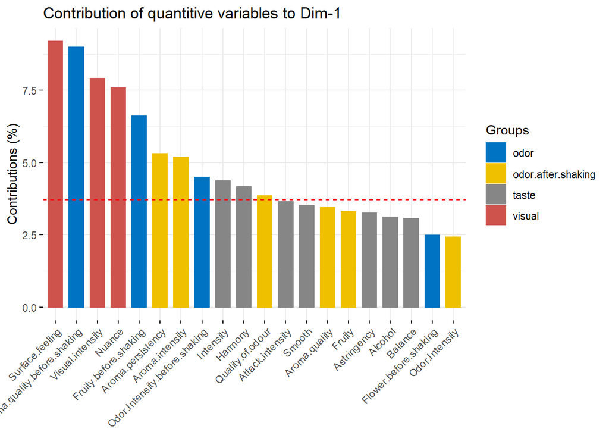

Factor 2

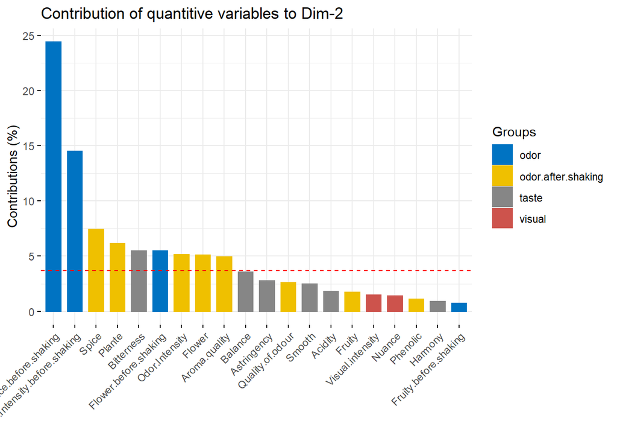

Factor 3

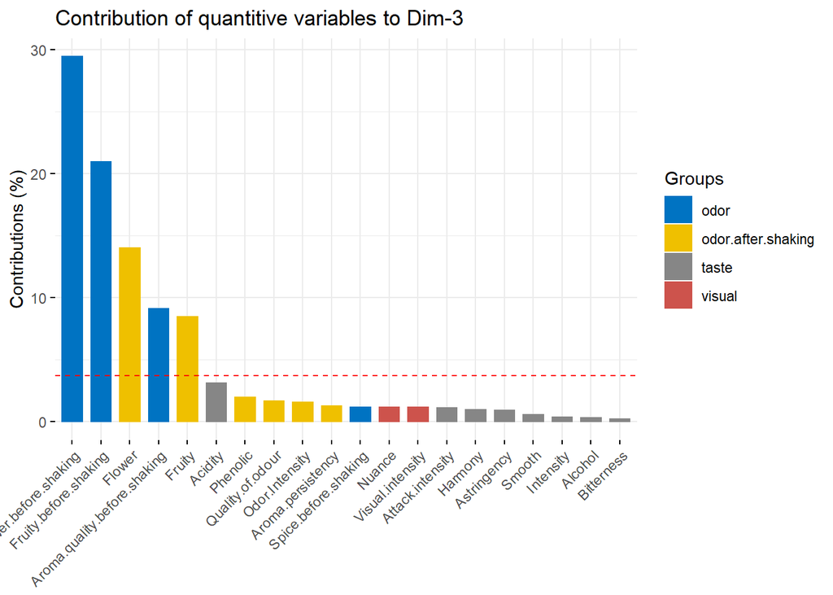

### Reporte del FA

Según la cantidad de factores, la función fa.diagram nos puede indicar cuál es la estructura factorial del análisis.

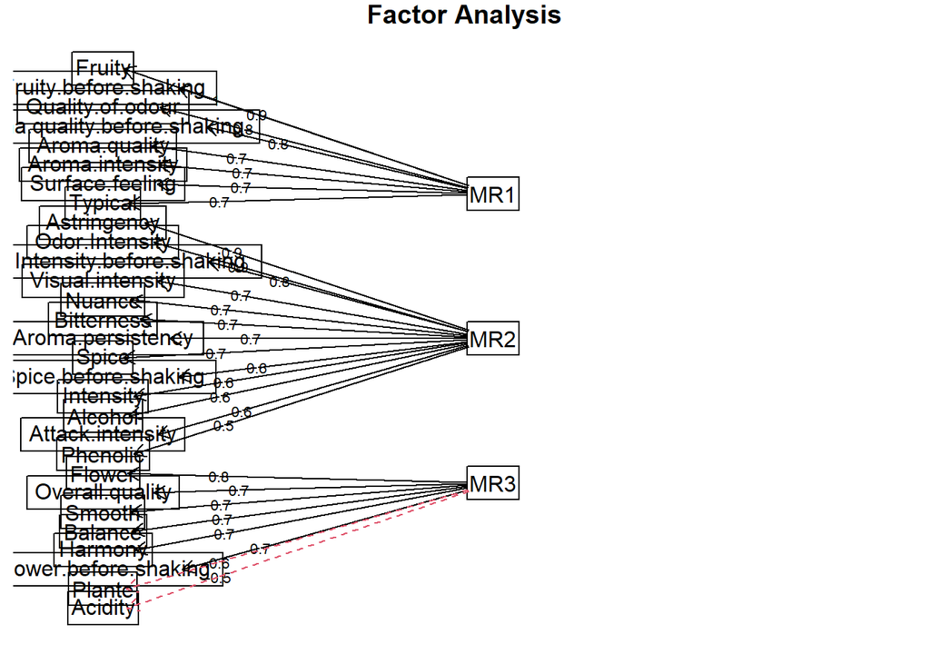

### Factores en plano 2D

LLevado a cabo el proceso de elegir la rotación y luego el número de componentes, podemos verificar que desde un inicio hasta la solución del problema, la estructura factorial del FA posee una forma de explicar los facores en un plano 2D. Veamos esto

Inicio: todas las variables

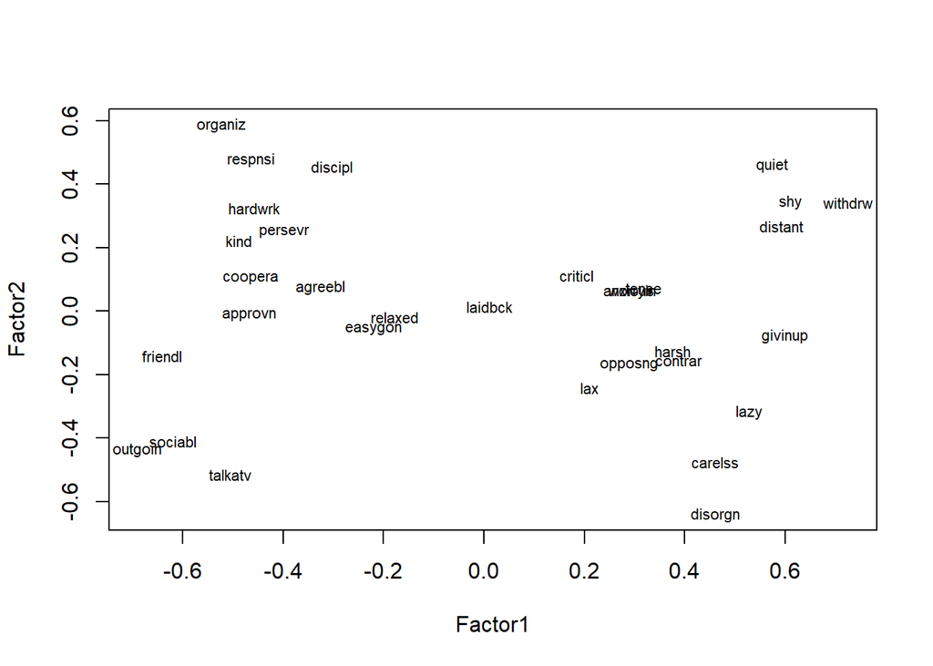

Intermedio: aplicación del FA y el acomodo de las variables

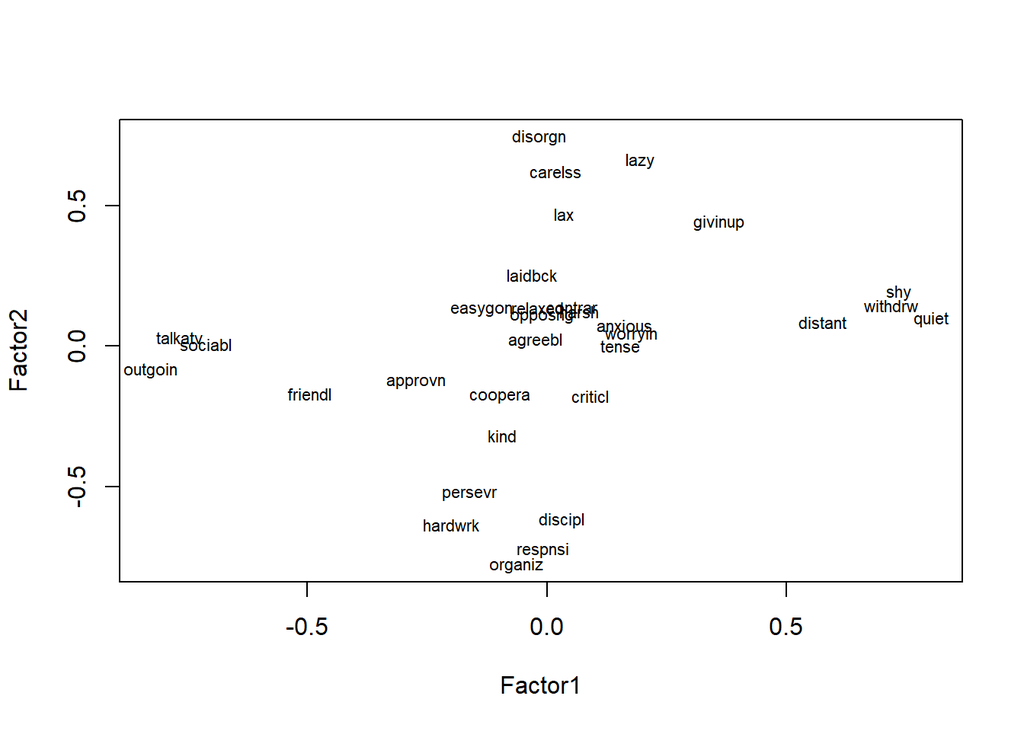

Final: estructura final del FA

Creamos la estructura factorial mediante el análisis de las cargas factoriales

```r
shy = rowMeans(cbind(personality$distant, personality$shy, personality$withdrw, personality$quiet))
outgoing = rowMeans(cbind(personality$talkatv, personality$outgoin, personality$sociabl))
hardworking = rowMeans(cbind(personality$hardwrk, personality$persevr, personality$discipl))
friendly = rowMeans(cbind(personality$friendl, personality$kind, personality$coopera, personality$agreebl, personality$approvn, personality$sociabl))
anxious = rowMeans(cbind(personality$tense, personality$anxious, personality$worryin))

# Combinando los factores y creando una nueva estructura de datos
combined_data = cbind(shy,outgoing,hardworking,friendly,anxious)
combined_data = as.data.frame(combined_data)
```

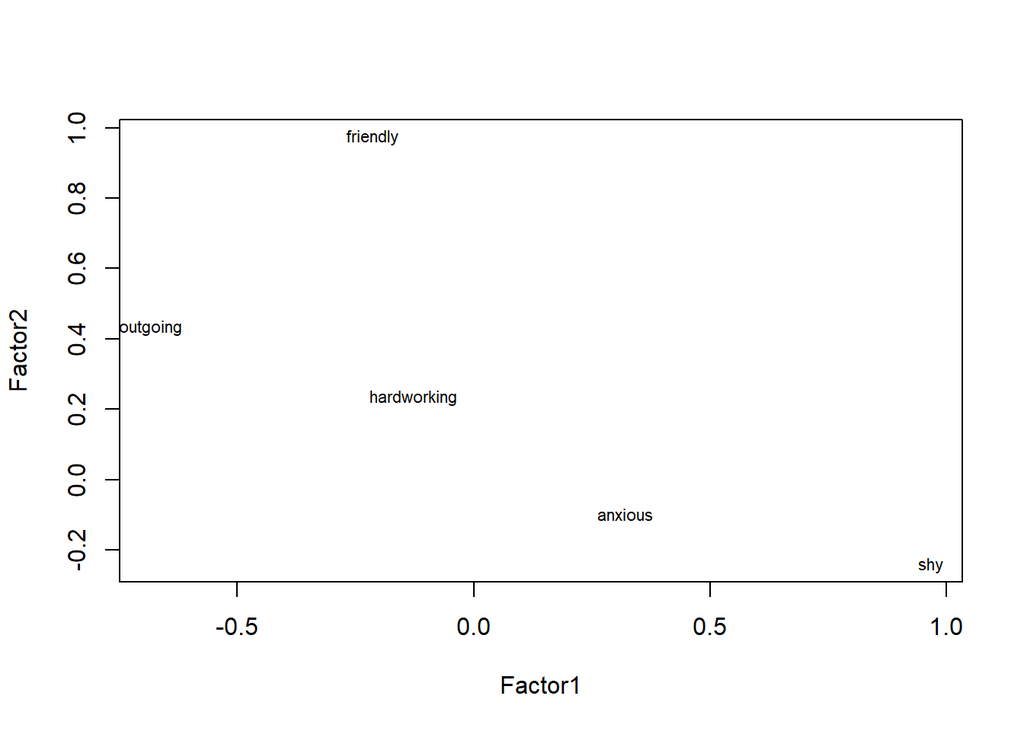

Puede que acá se estimen diversos modelos de FA, con diversas rotaciones, con tal de ver una mejorar separación, y hasta aglomeración de los factores.

## Otros análisis

### Otros análisis de las variables: circulos de correlación

#### Correlación entre variables cuanti y las dimensiones

Flechas

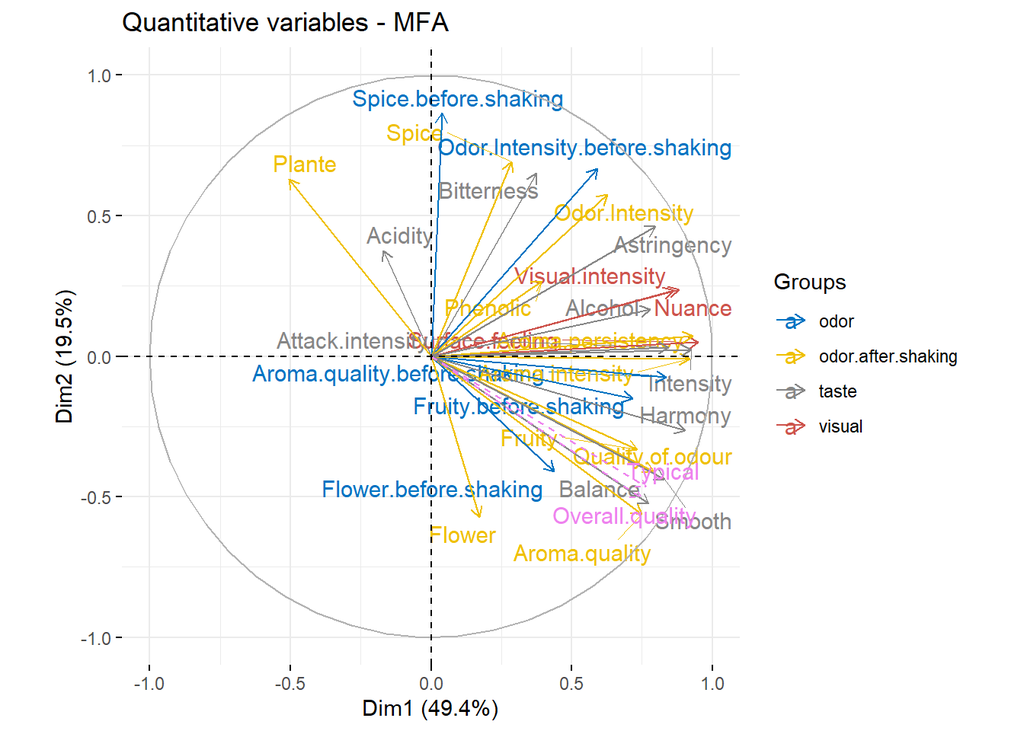

Puntos

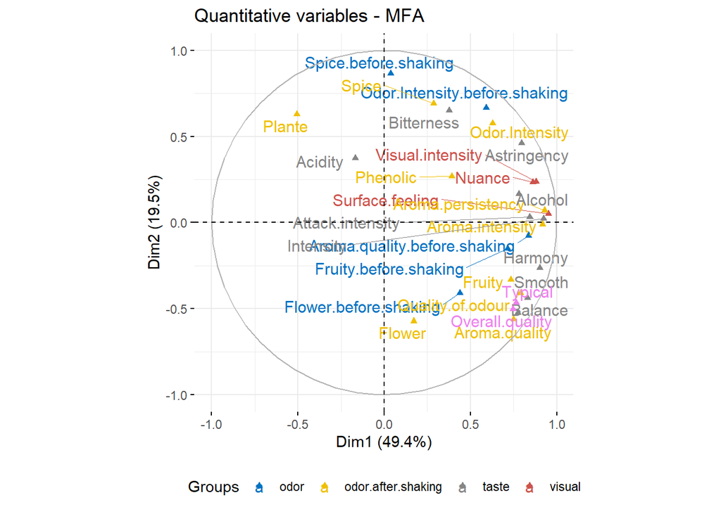

#### COntribución de las variables

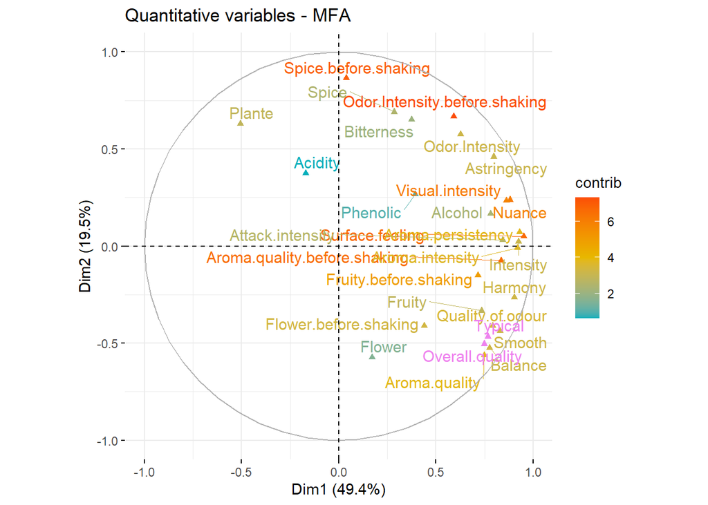

### Análisis de los individuos en un FA

También podemos analizar a los individuos en el FA. Creo que no es lo primordial, pero se puede.

Calidad de representación del individuos al análisis de FA

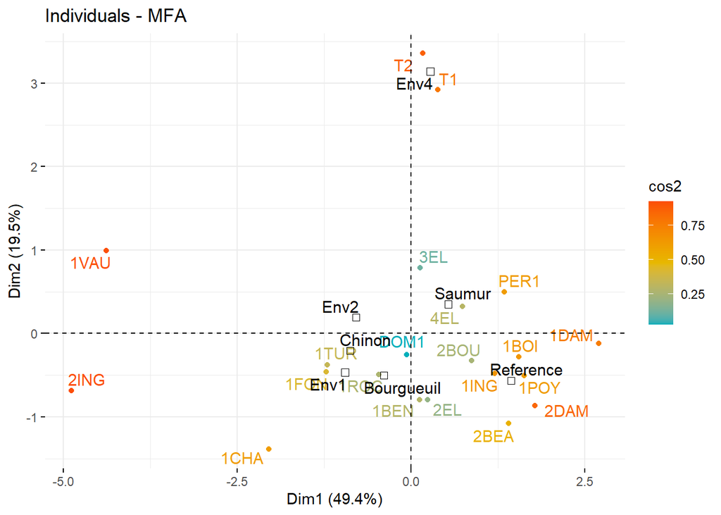

Individuos perteneciente a cierto grupo o categorias

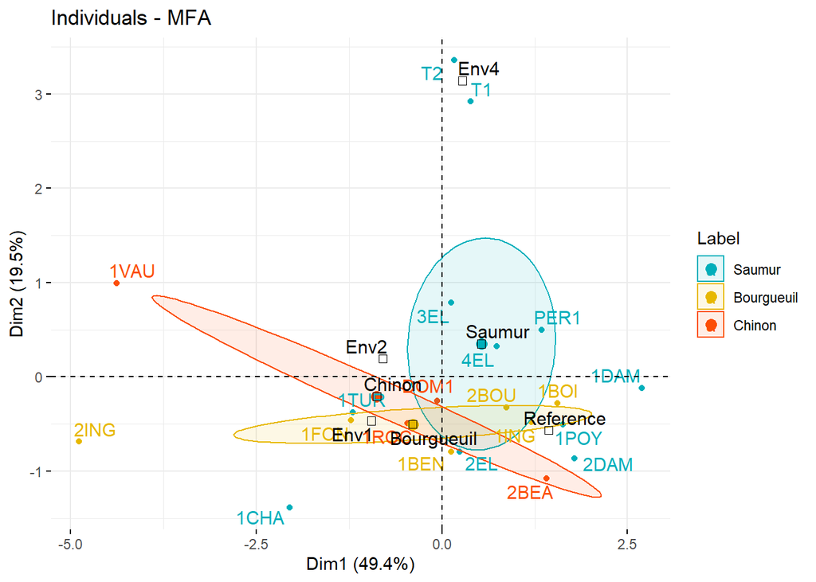

Otra variante

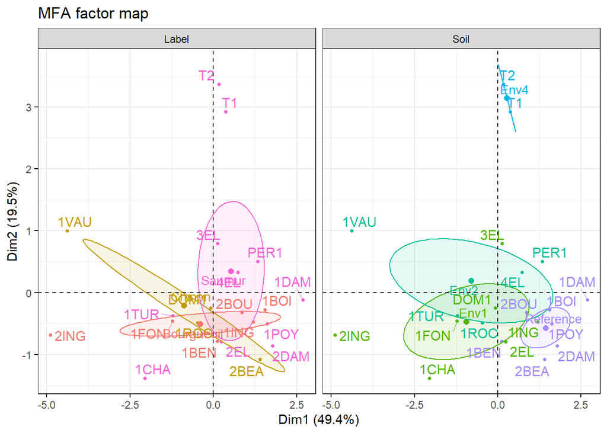

Los resultados para individuos obtenidos del análisis realizado con un solo grupo se denominan individuos parciales. En otras palabras, un individuo considerado desde el punto de vista de un solo grupo se llama individuo parcial.

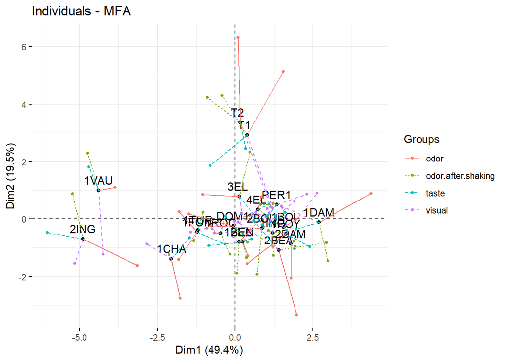

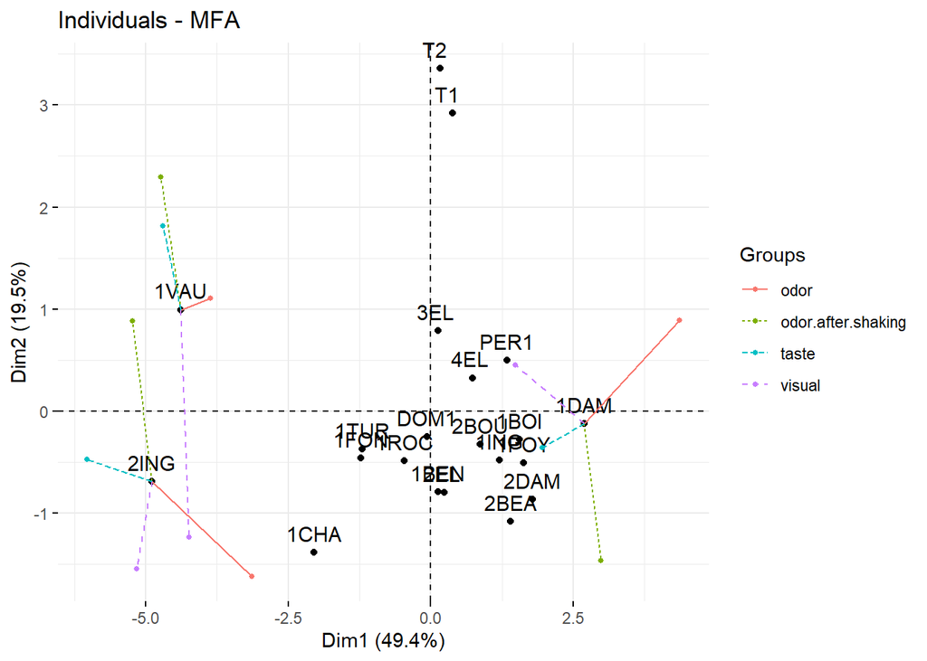

## Análisis Factorial Confirmatorio

El presente curso no cubre el CFA, pero pueden obtener algunas referencias de como proceder en R según los siguientes enlaces:

https://rpubs.com/razzag/320895 http://www.statpower.net/Content/312/Handout/Confirmatory%20Factor%20Analysis%20with%20R.pdf https://www.methodsconsultants.com/tutorial/confirmatory-factor-analysis-using-the-sem-package-in-r/ https://www.r-bloggers.com/all-together-now-confirmatory-factor-analysis-in-r/

La librería más utilizada es “lavaan”, con su funcióin cfa()

```r
#Librería

# library(lavaan)

#función

#cfa(model, data=ex_data)
```